# AIT526_Team4_sys

AIT-526-DL1 - Natural Language Processing

Final Project - "Sentiment Analysis and Recommendations for Hotels"

Team-4

Meghna Kattekola(G01463794)

Ramya Sri Thallapally (G01454183)

Srija Anasuri (G01446546)

```python
#Importing Libraries:
import pandas as pd
from nltk.tokenize import word_tokenize
from nltk.corpus import stopwords
from nltk.sentiment.vader import SentimentIntensityAnalyzer
import string
```

```python
#Loading the dataset
data = pd.read_csv("C:/Users/thall/Downloads/Hotel_Reviews.csv/Hotel_Reviews.csv")
```

```python
#Tokenize function
#It converts text to lowercase and filters out non-alphanumeric tokens.
def tokenize(text):
    tokens = word_tokenize(text)
    tokens = [token.lower() for token in tokens if token.isalnum()]
    return tokens
```

```python
#Preprocess function
def preprocess(text):
    text = text.lower()
    text = text.translate(str.maketrans('', '', string.punctuation))
    return text
```

```python
#Defining aspects of interest
aspects = ['location', 'staff', 'cleanliness', 'amenities', 'service']
```

```python
#Initializing sentiment analyzer
sid = SentimentIntensityAnalyzer()
```

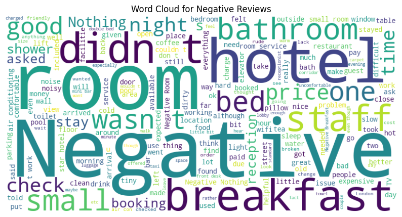

```python
#Performing word cloud for Negative Reviews
from wordcloud import WordCloud
import matplotlib.pyplot as plt

# Combine negative reviews into a single string
negative_text = ' '.join(data['Negative_Review'])

# Generate word cloud for negative reviews
negative_wordcloud = WordCloud(width=800, height=400, background_color="white").generate(negative_text)

# Plot word cloud for negative reviews
plt.figure(figsize=(10, 6))
plt.imshow(negative_wordcloud, interpolation="bilinear")
plt.title('Word Cloud for Negative Reviews')
plt.axis("off")
plt.show()
```

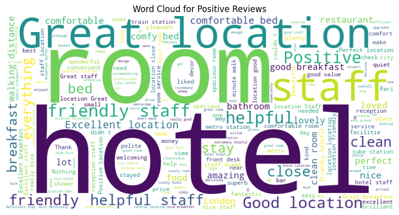

```python
#Performing word cloud for Positive Reviews
# Combine positive reviews into a single string
positive_text = ' '.join(data['Positive_Review'])

# Generate word cloud for positive reviews
positive_wordcloud = WordCloud(width=800, height=400, background_color="white").generate(positive_text)

# Plot word cloud for positive reviews
plt.figure(figsize=(10, 6))
plt.imshow(positive_wordcloud, interpolation="bilinear")
plt.title('Word Cloud for Positive Reviews')
plt.axis("off")
plt.show()
```

Aspect-Based Sentiment Analysis:

Separating negative and positive reviews.

Tokenizing and preprocessing review text for each aspect.

Checking if aspect words are present.

Computing sentiment scores using VADER.

Categorizing reviews as positive, negative, or neutral.

Accumulating counts for each sentiment category and aspect.

```python
#Performing aspect-based sentiment analysis for negative reviews
aspect_sentiment_negative = {aspect: {'positive': 0, 'negative': 0, 'neutral': 0} for aspect in aspects} #Initializing a dictionary to store aspect-based sentiment analysis results for negative reviews

#Iterate through each aspect
for aspect in aspects:
    #Iterate through each positive review in the dataset
    for review in data['Negative_Review']:
        tokens = tokenize(preprocess(review))

        #Check if the current aspect is mentioned in the review
        if aspect in tokens:
            scores = sid.polarity_scores(review)
            #Categorizing Sentiment Based on Compound Score:
            #If compound >= 0.05, the sentiment is counted as positive for that aspect.
            #If compound <= -0.05, it is counted as negative.
            #Scores between -0.05 and 0.05 are counted as neutral.
            if scores['compound'] >= 0.05: #Positive sentiment
                aspect_sentiment_negative[aspect]['positive'] += 1
            elif scores['compound'] <= -0.05: #Negative sentiment
                aspect_sentiment_negative[aspect]['negative'] += 1
            else: #Neutral sentiment
                aspect_sentiment_negative[aspect]['neutral'] += 1
```

```python
#Performing aspect-based sentiment analysis for positive reviews
aspect_sentiment_positive = {aspect: {'positive': 0, 'negative': 0, 'neutral': 0} for aspect in aspects} #Initializing a dictionary to store aspect-based sentiment analysis results for positive reviews

#Iterate through each aspect
for aspect in aspects:
    #Iterate through each positive review in the dataset
    for review in data['Positive_Review']:
        tokens = tokenize(preprocess(review)) #Tokenize and preprocess the review text

        #Check if the current aspect is mentioned in the review
        if aspect in tokens:
            scores = sid.polarity_scores(review) #Perform sentiment analysis on the review
            #Update sentiment counts based on the sentiment score
            if scores['compound'] >= 0.05: #Positive sentiment
                aspect_sentiment_positive[aspect]['positive'] += 1
            elif scores['compound'] <= -0.05: #Negative sentiment
                aspect_sentiment_positive[aspect]['negative'] += 1
            else: #Neutral sentiment
                aspect_sentiment_positive[aspect]['neutral'] += 1
```

```python
#Displaying aspect-based sentiment analysis results for negative reviews
print("Sentiment Analysis Results for Negative Reviews:")
for aspect, sentiment in aspect_sentiment_negative.items():
    print(f'Aspect: {aspect}')
    print(f'Positive: {sentiment["positive"]}, Negative: {sentiment["negative"]}, Neutral: {sentiment["neutral"]}')
```

```
Sentiment Analysis Results for Negative Reviews:
Aspect: location
Positive: 4170, Negative: 3875, Neutral: 2671
Aspect: staff
Positive: 11871, Negative: 17881, Neutral: 4341
Aspect: cleanliness
Positive: 461, Negative: 670, Neutral: 353
Aspect: amenities
Positive: 338, Negative: 458, Neutral: 154
Aspect: service
Positive: 5000, Negative: 9072, Neutral: 3009
```